# M. Wright, BI624 PS1

### Part 1

**1. Run FastQC on our 4 files**

```bash
ml easybuild intel/2017a FastQC
fastqc -o . --noextract /projects/bgmp/2017_sequencing/demultiplexed/2_2B_control_S2_L008_R1_001.fastq.gz /projects/bgmp/2017_sequencing/demultiplexed/2_2B_control_S2_L008_R2_001.fastq.gz /projects/bgmp/2017_sequencing/demultiplexed/7_2E_fox_S6_L008_R1_001.fastq.gz /projects/bgmp/2017_sequencing/demultiplexed/7_2E_fox_S6_L008_R2_001.fastq.gz
```

**Quality Score Distributions and Per-Base N Content**

**2_2B_control R1**

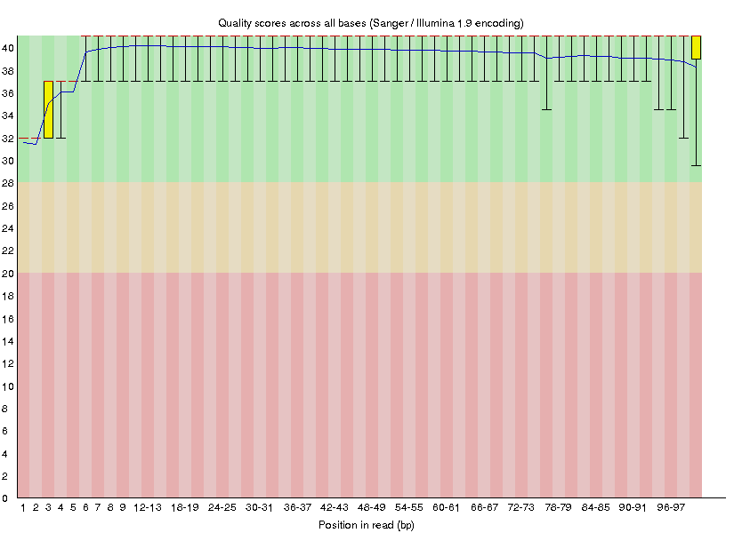

2_2B_control R1 Per-Base Quality

**2_2B_control R2**

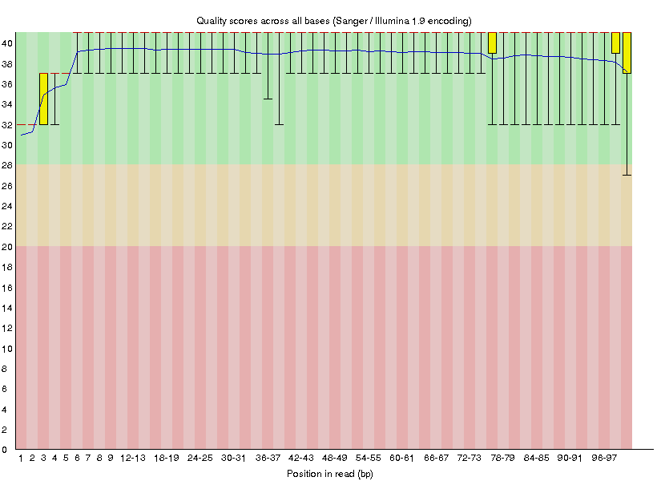

2_2B_control R2 Per-Base Quality

**7_2E_fox R1**

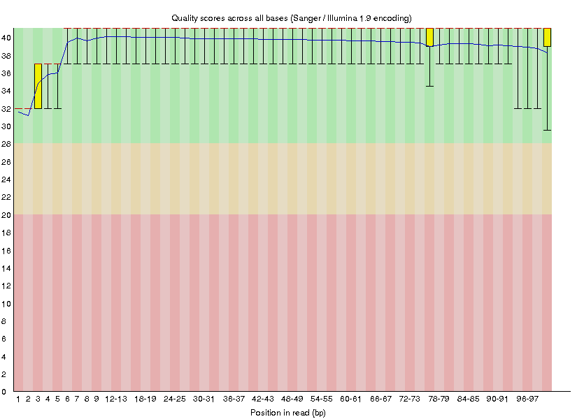

7_2E_fox R1 Per-Base Quality

**7_2E_fox R2**

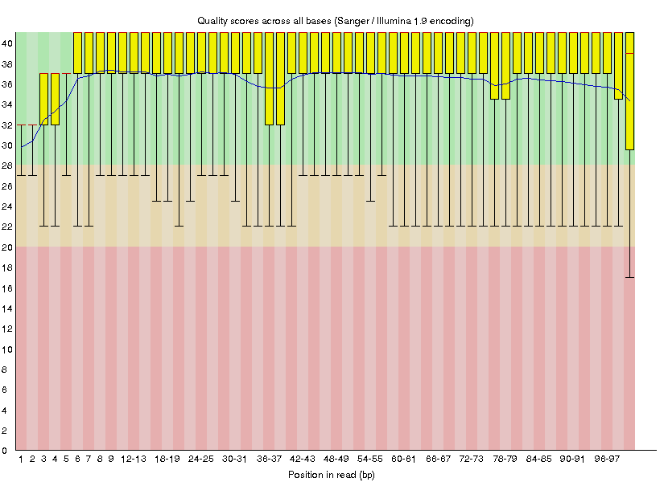

7_2E_fox R2 Per-Base Quality

**2. I also evaluated the files using my barhopping.py script from the index hopping assignment. barhopping.py is included with this assignment**

**2_2B_control R1**

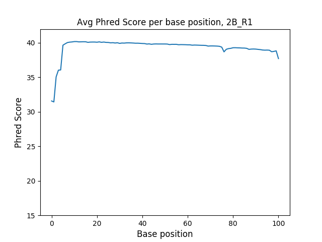

2_2B_control R1 Per-Base Quality

**2_2B_control R2**

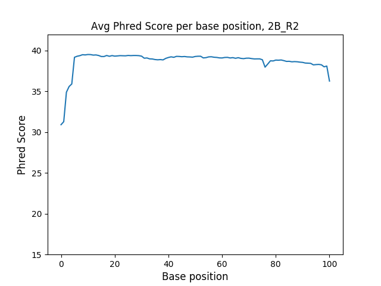

2_2B_control R2 Per-Base Quality

**7_2E_fox R1**

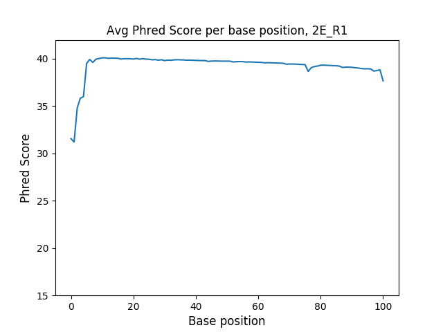

7_2E_fox R1 Per-Base Quality

**7_2E_fox R2**

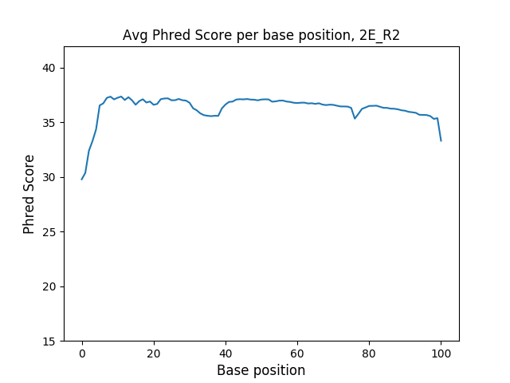

7_2E_fox R2 Per-Base Quality

The FastQC results match up to my own with regards to the quality plots. However, the FastQC plots are more refined, with error bars and such, and were generated much quicker than mine (<10 min vs. ~30 min). This is probably because FastQC is written in Java, while my program is a relatively rudimentary implementation in Python.

### Part 2

**3. Describe the different adapter trimming options and use one to trim adapter sequences**

**process_shortreads** - process_shortreads is included in the STACKS package, and is also capable of processing single or paired-end reads. As with cutadapt, you must supply it with adapter sequences. It also supplies several options for read cleaning, including the ability to remove reads containing N’s as well as reads with low quality scores or that didn’t pass Illumina’s chastity filter. process_shortreads also gives you the ability to supply and rescue barcodes from the reads.

**Adapter sequences**

R1 adapter (3’): GATCGGAAGAGCACACGTCTGAACTCCAGTCACNNNNNNNNATCTCGTATGCCGTCTTCTGCTTG

R2 adapter (#’): AATGATACGGCGACCACCGAGATCTACACNNNNNNNNACACTCTTTCCCTACACGACGCTCTTCCGATC

R2 revcomp (3’): GATCGGAAGAGCGTCGTGTAGGGAAAGAGTGTNNNNNNNNGTGTAGATCTCGGTGGTCGCCGTATCATT

```bash
cutadapt -a GATCGGAAGAGCACACGTCTGAACTCCAGTCACNNNNNNNNATCTCGTATGCCGTCTTCTGCTTG
-A GATCGGAAGAGCGTCGTGTAGGGAAAGAGTGTNNNNNNNNGTGTAGATCTCGGTGGTCGCCGTATCATT
-o fastq-out/2B-R1.fastq -p fastq-out/2B-R2.fastq
/projects/bgmp/2017_sequencing/demultiplexed/2_2B_control_S2_L008_R1_001.fastq.gz
/projects/bgmp/2017_sequencing/demultiplexed/2_2B_control_S2_L008_R2_001.fastq.gz

cutadapt -a GATCGGAAGAGCACACGTCTGAACTCCAGTCACNNNNNNNNATCTCGTATGCCGTCTTCTGCTTG
-A GATCGGAAGAGCGTCGTGTAGGGAAAGAGTGTNNNNNNNNGTGTAGATCTCGGTGGTCGCCGTATCATT
-o fastq-out/2E-R1.fastq -p fastq-out/2E-R2.fastq
/projects/bgmp/2017_sequencing/demultiplexed/7_2E_fox_S6_L008_R1_001.fastq.gz
/projects/bgmp/2017_sequencing/demultiplexed/7_2E_fox_S6_L008_R2_001.fastq.gz
```

**4. Plot length distribution of trimmed reads**

Make length distributions of resulting files

```bash
cat 2B-R1.fastq | grep -E -A 1 --no-group-separator "^@K00337" | grep -v "^@K00337" | awk '{print length($0);}' | sort | uniq -c > 2B-R1-len.txt

cat 2B-R2.fastq | grep -E -A 1 --no-group-separator "^@K00337" | grep -v "^@K00337" | awk '{print length($0);}' | sort | uniq -c > 2B-R2-len.txt

cat 2E-R1.fastq | grep -E -A 1 --no-group-separator "^@K00337" | grep -v "^@K00337" | awk '{print length($0);}' | sort | uniq -c > 2E-R1-len.txt

cat 2E-R2.fastq | grep -E -A 1 --no-group-separator "^@K00337" | grep -v "^@K00337" | awk '{print length($0);}' | sort | uniq -c > 2E-R2-len.txt
```

Plot the length distributions

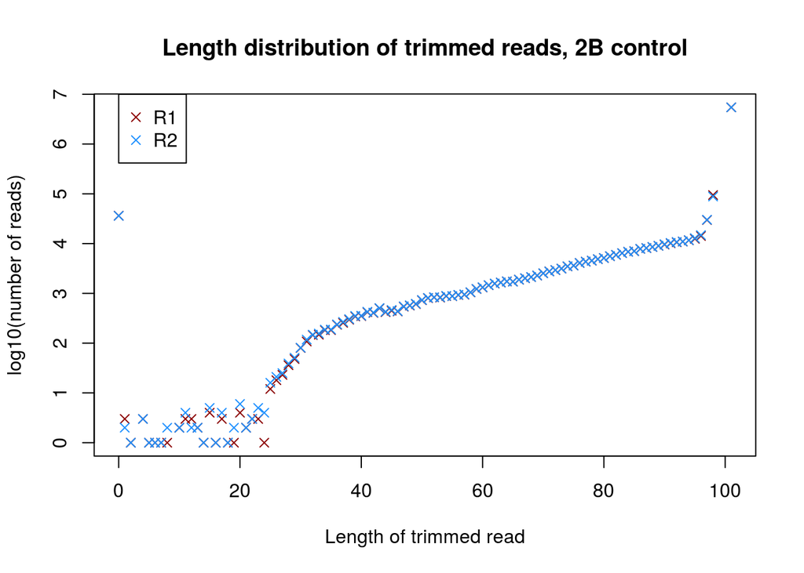

```r
BR1<-read.table("myfiles/2B-R1-len.txt")
BR2<-read.table("myfiles/2B-R2-len.txt")
{plot(log(BR1$V1, 10)~BR1$V2, pch=4, col="darkred", xlab="Length of trimmed read", ylab="log10(number of reads)", main = "Length distribution of trimmed reads, 2B control")
points(log(BR2$V1, 10)~BR2$V2, pch=4, col="dodgerblue")
legend(0, 7, legend = c("R1", "R2"), col=c("darkred", "dodgerblue"), pch=4)}
```

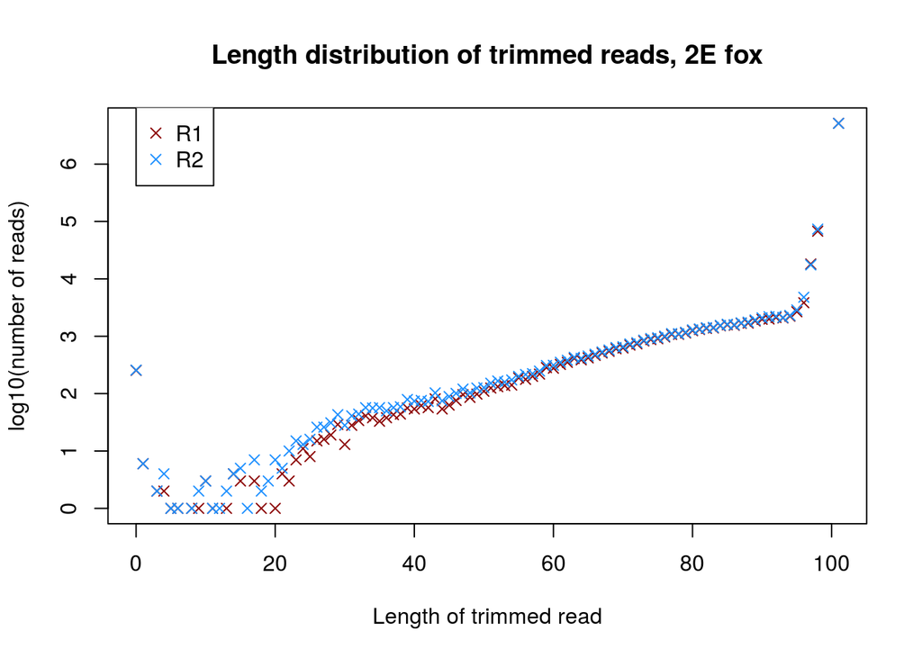

```r
ER1<-read.table("myfiles/2E-R1-len.txt")
ER2<-read.table("myfiles/2E-R2-len.txt")

{plot(log(ER1$V1, 10)~ER1$V2, pch=4, col="darkred", xlab="Length of trimmed read", ylab="log10(number of reads)", main = "Length distribution of trimmed reads, 2E fox")
points(log(ER2$V1, 10)~ER2$V2, pch=4, col="dodgerblue")
legend(0, 7, legend = c("R1", "R2"), col=c("darkred", "dodgerblue"), pch=4)}
```

**5. Are these graphs consistent with the fragment analyzer?**

These distributions were not quite what I expected. I had libraries 2_2B and 7_2E, which both contained roughly similar amounts of reads (~5.75M vs. ~5.25M), but the fragment analyzer results for 2_2B shows a tighter distribution between 300-1000 bp, while 7_2E shows a clear lip between 200-300bp. However, you see ~35,000 reads that have been trimmed to 0 in 2_2B and only about ~250 which have been trimmed to 0 in the 7_2E sample. Based on the fragment analyzer, I would have expected the opposite result.

### Part 3

**6. Find rRNA sequences from mouse, build BLAST db and BLAST against our reads**

Download ncRNA file, fix the fasta using fixfasta.py, and extract rRNA sequences. fixfasta.py is included with this assignment.

```bash
wget ftp://ftp.ensembl.org/pub/release-90/fasta/mus_musculus/ncrna/Mus_musculus.GRCm38.ncrna.fa.gz

./fixfasta.py -i Mus_musculus.GRCm38.ncrna.fa -o Mouse-ncRNA.fa

grep --no-group-separator -A 1 "rRNA" Mouse-ncRNA.fa > Mouse-rRNA.fa
```

Build gsnap database on our rRNA db, run gsnap on both paired sets, then use sam-parse.py to determine the number and percent of mapped/unmapped reads. sam-parse.py is included with the assignment.

```bash
module load gmap-gsnap/2017-09-11

gmap_build -D db/ -d Mouse-rRNA Mouse-rRNA.fa

gsnap -D db/Mouse-rRNA/ -d Mouse-rRNA -N 1 -t 12 -A sam --allow-pe-name-mismatch fastq-out/2B-R1.fastq fastq-out/2B-R2.fastq > 2_2B_rRNA.sam

gsnap -D db/Mouse-rRNA/ -d Mouse-rRNA -N 1 -t 12 -A sam --allow-pe-name-mismatch fastq-out/2E-R1.fastq fastq-out/2E-R1.fastq > 7_2E_rRNA.sam

./sam-parse.py -i 2_2B_rRNA.sam
Unmapped: 11399705
Mapped: 46015
% Mapped: 0.4020280069755332

./sam-parse.py -i 7_2E_rRNA.sam
Unmapped: 10314132
Mapped: 241195
% Mapped: 2.2850547406063306
```

**7. Demonstrate that the SF-seq data is strand-specific**

I looked it up online and one person recommended using the infer_experiment.py script from the RSeQC program. This requires a bam file generated from aligning reads to the genomic database. The general pipeline would be to generate a GSNAP database from the mouse chromosomal sequences, then align our reads to them using gsnap. Following that, convert the .sam file into a .bam file using samtools, then use the .bam file in infer_experiment.

Something like:

```bash
gmap_build -D . -g -d mousedb mouse Mus_musculus.GRCm38.dna.chromosome.*.fa.gz

gsnap -D db/Mouse-genome/ -d mousedb -N 1 -t 26 -A sam --allow-pe-name-mismatch fastq-out/2B-R1.fastq fastq-out/2B-R2.fastq > 2_2B_genome.sam

samtools view -b -o 2_2B_genome.bam 2_2B_genome.sam

infer_experiment.py -i 2_2B_genome.sam -r mm10_RefSeq.bed
```

I would show you the results if I had started earlier and was able to make the database and align the reads.

~